# Introduction

The [CIFAR-10](https://www.cs.toronto.edu/~kriz/cifar.html) dataset consits of 60,000 color images of size 32 x 32 collected by by Krizhevsky, Nair, and Hinton. The dataset has 10 classes, each class having 6,000 images which is divided in to two groups:

- Training: 50,000 images
- Testing: 10,000 images

The classes are completely mutually exclusive. There is no overlap between automobiles and trucks. "Automobile" includes sedans, SUVs, things of that sort. "Truck" includes only big trucks. Neither includes pickup trucks.

Johannes Schade (5564109)

Yolanda Seifert (5477060)

David Bauer (5398867)

# All questions answered here

The first simple convnet overfitted very much, having a near 100% accuracy on the training set but only 39% on the test set, which is still a lot better than chance.

With the first larger convnet we have less good results with the accuracy not outperforming chance. This could be explained by the much larger size of the convnet, a lot more features need to be learnt and the net doesn't manage to improve. Always predicting the same class ensures a 10% success rate

Adding Batch Normalization improves our net by alot jumping to ca. 48%, still overfitted strongly though.

Image Augmentation adds randomness to the training data which will reduce overfitting aswell as teaching features independently of the orientation of an image. In our case the improvement was minimal and we observed a reduction of accuracy and slightly more overfitting. Tuning the randomness of the transformations might help.

# Plots

The first and second plots don't look to have a lot of structure, but the spread of the data is less in the simple model, maybe meaning there is some more structure added to the distribution of classes.

In the third there is obvious structure, some of the data points seam to mass in the bottom where they are less differentiated but certain labels are clearly seperated from the rest and some classes that "should" have common features (cars and trucks/ cats and dogs) tend to overlap.

===========================================

In the following, you will apply different algorithms to the task of object recognition in the images of the aforementioned dataset. Above each cell is a text file with a task for you to complete. If you do not own a laptop with a capable GPU, you can use [google colab](https://colab.research.google.com). Click File -> Upload Notebook to upload your exercise. Then on the right side of the screen you will find Connect -> View Resources -> Change Runtime Type. Here you should have three options to choose from: None, GPU, and TPU. Select GPU as your runtime type. Note that in the non-Pro version, you can only use GPU for a limited time. However, the exercise was performed with the free version without any problems or issues, so you do not need to upgrade to the Pro version to complete the exercise.

Importing required packages

```python
import os

from collections import Counter

import numpy as np

from matplotlib import pyplot as plt

from sklearn.model_selection import train_test_split, GridSearchCV
from sklearn.svm import SVC
from sklearn.decomposition import PCA
from sklearn.preprocessing import StandardScaler
from sklearn.pipeline import Pipeline
from sklearn.metrics import confusion_matrix, classification_report
from sklearn import metrics

import tensorflow as tf
from tensorflow.keras import Input, Model, layers, losses, callbacks, optimizers
from tensorflow.keras.preprocessing.image import ImageDataGenerator
```

- Load the data, rescale it and split the **original training** data into training (10000 samples), validation (1000 samples ) and test set (1000 samples)
- Print the shape of your training set
- Print the number of samples in each class
- Compute the mean and standard deviation of your training and test set

```
# x_train = (50000, 32, 32, 3), # y_train = (50000, 1)
train :  mean 0.4735345 std 0.25126073
train :  mean 0.47146308 std 0.24976675
```

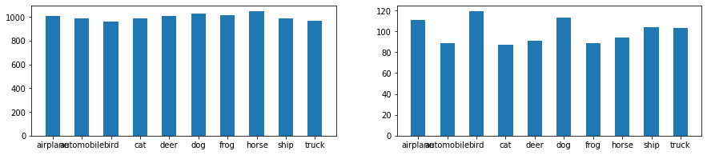

```python
# Code for loading the data
(x_train, y_train), (x_test, y_test) = tf.keras.datasets.cifar10.load_data()
# Classes (are given)
classes = np.array(['airplane', 'automobile', 'bird', 'cat', 'deer', 'dog', 'frog', 'horse', 'ship', 'truck'])

# Code for printing the shape of your training set
print(f'# x_train = {x_train.shape}, # y_train = {y_train.shape}')

# Code for rescaling the images
def preprocess_images(x):
    return x.astype('float32')/255.
xtrain = preprocess_images(x_train)

# Code for splitting the data into train/val/test set
Xtrain_, Xrest_, Ytrain, Yrest_ = train_test_split(xtrain, y_train, train_size=10000)
Xval_, Xrest_, Yval, Yrest_ = train_test_split(Xrest_, Yrest_, train_size=1000)
Xtest_, Xrest_, Ytest, Yrest_ = train_test_split(Xrest_, Yrest_, train_size=1000)

# Code for printing the # of samples in each class
def count_samples(ls):
    distribution = np.zeros(10)
    for i in ls:
        distribution[i] += 1
    return distribution


train_distribution = count_samples(Ytrain)
test_distribution = count_samples(Ytest)

fig, (ax1, ax2) = plt.subplots(1, 2, figsize=(15,3))
ax1.bar(classes,  train_distribution, width=0.5)
ax2.bar(classes,  test_distribution, width=0.5)

# Code for computing the mean and std of the training and test set

mean_train = np.mean(Xtrain_)
std_train = np.std(Xtrain_)

mean_test = np.mean(Xtest_)
std_test = np.std(Xtest_)

print("train : ", 'mean', mean_train, 'std', std_train)
print("train : ", 'mean', mean_test, 'std', std_test)
```

Plot a 10 x 10 grid with some random data points, each row representing one of the 10 classes with 10 images from that class.

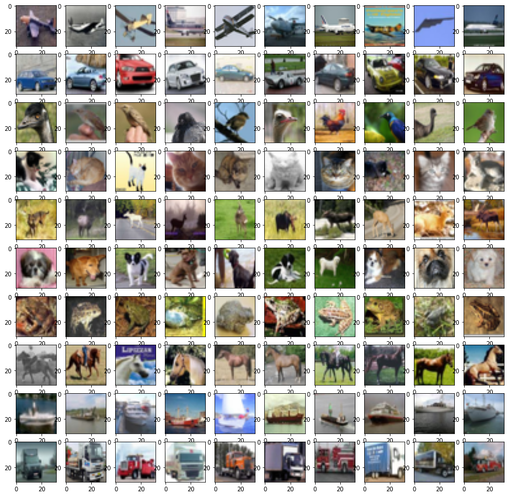

```python
# Code for plotting
def get_data_points(num_class, size):
    return np.random.choice(np.where(Ytrain == num_class)[0], size, replace=False)

idxs = np.append(get_data_points(0, 10), [get_data_points(1, 10), get_data_points(2, 10), get_data_points(3, 10), get_data_points(4, 10),
                 get_data_points(5, 10), get_data_points(6, 10), get_data_points(7, 10), get_data_points(8, 10), get_data_points(9, 10)])

fig, axs = plt.subplots(10,10,figsize=(15,15))
for idx, ax in zip(idxs, axs.flatten()):
    ax.imshow(Xtrain_[idx])
```

Use the convnet from first notebook (Convolutional Neural Network in tensorflow using keras API cell) and train on cifar-10 for **100** epochs.

- Create a checkpoint to save the best model (see [ModelCheckpoint](https://keras.io/api/callbacks/model_checkpoint/))
- Use the trained model to make predictions on the test data
- Print the **classification_report**
- Print the **confusion_matrix**
- Plot training loss vs. validation loss
- Plot training accuracy vs. validation accuracy

```python
# Code for training on Cifar-10
def cifar10_clf(input_shape=(32,32,3), n_classes=10):
    inx = Input(input_shape)
    x = layers.Conv2D(32, kernel_size=(3, 3), strides=2, padding='same', activation='relu')(inx)
    x = layers.Conv2D(64, kernel_size=(3, 3), strides=2, padding='same', activation='relu')(x)
    x = layers.Conv2D(128, kernel_size=(3, 3), strides=2, padding='same', activation='relu')(x)
    x = layers.Flatten()(x)
    x = layers.Dense(128, activation='relu')(x)
    x = layers.Dense(n_classes)(x)
    return Model(inx, x)

clf_cifar10 = cifar10_clf()
clf_cifar10.summary()

# select loss function and optimizer
loss = losses.CategoricalCrossentropy(from_logits=True)
opt = optimizers.Nadam(learning_rate=1e-2)
clf_cifar10.compile(loss=loss, optimizer=opt, metrics=['accuracy'])

# preprocess data: scaling of images, one-hot encoding of labels
def preprocess_tf(x, y):
    return x, tf.one_hot(y, depth=10, axis=-1)

trainset = tf.data.Dataset.from_tensor_slices((Xtrain_, Ytrain.flatten())).shuffle(Xtrain_.shape[0]).batch(256).map(preprocess_tf)
valset = tf.data.Dataset.from_tensor_slices((Xval_, Yval.flatten())).batch(1000).map(preprocess_tf)

# callback for saving model
MdlCpt = callbacks.ModelCheckpoint('cpt/convnet_cifar10_1', save_best_only=True)

hist = clf_cifar10.fit(trainset, validation_data=valset, epochs=100, callbacks=[MdlCpt])
```

```
Model: "model_2"
_________________________________________________________________
 Layer (type)                Output Shape              Param #
=================================================================
 input_2 (InputLayer)        [(None, 32, 32, 3)]       0

 conv2d_3 (Conv2D)           (None, 16, 16, 32)        896

 conv2d_4 (Conv2D)           (None, 8, 8, 64)          18496

 conv2d_5 (Conv2D)           (None, 4, 4, 128)         73856

 flatten_1 (Flatten)         (None, 2048)              0

 dense_2 (Dense)             (None, 128)               262272

 dense_3 (Dense)             (None, 10)                1290

=================================================================
Total params: 356,810
Trainable params: 356,810
Non-trainable params: 0
_________________________________________________________________
```

[output not shown]

[output not shown]

[output not shown]

[output not shown]

[output not shown]

[output not shown]

[output not shown]

[output not shown]

```python
# Code for prediction
# Using the best model
clf2 = tf.keras.models.load_model('cpt/convnet_cifar10_1')
pred = tf.argmax(clf2(Xtest_), axis=-1)
```

```python
# Code for classification report and confusion matric
print(classification_report(Ytest, pred))
print(confusion_matrix(Ytest, pred))
```

```
              precision    recall  f1-score   support

           0       0.32      0.50      0.39       111
           1       0.35      0.65      0.45        89
           2       0.43      0.22      0.29       119
           3       0.31      0.22      0.26        87
           4       0.36      0.31      0.33        91
           5       0.32      0.22      0.26       113
           6       0.38      0.51      0.44        89
           7       0.53      0.40      0.46        94
           8       0.43      0.57      0.49       104
           9       0.48      0.26      0.34       103

    accuracy                           0.38      1000
   macro avg       0.39      0.39      0.37      1000
weighted avg       0.39      0.38      0.37      1000

[[56 15  6  1  2  1  0  2 27  1]
 [10 58  0  0  2  1  4  3  5  6]
 [24  9 26  7 13  8 13  8  8  3]
 [ 8  3  6 19  8 14 16  5  4  4]
 [13  5 10  2 28  8 10  4  9  2]
 [11  5  7 19 11 25 16  7  9  3]
 [ 4 11  3  5  5  8 45  2  1  5]
 [15  6  2  3  5 10  9 38  4  2]
 [25 12  1  1  2  1  0  0 59  3]
 [ 7 43  0  4  2  2  4  3 11 27]]
```

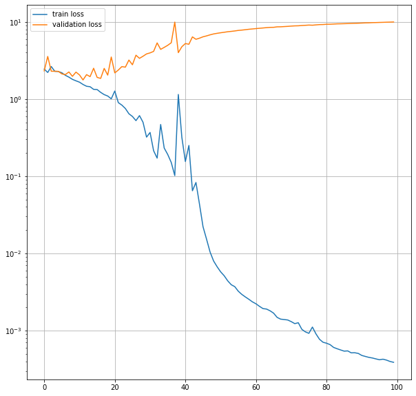

```python
# Code for training loss vs. val loss
plt.figure(figsize=(10,10))
plt.semilogy(hist.history['loss'], label='train loss')
plt.semilogy(hist.history['val_loss'], label='validation loss')
plt.legend()
plt.grid()
```

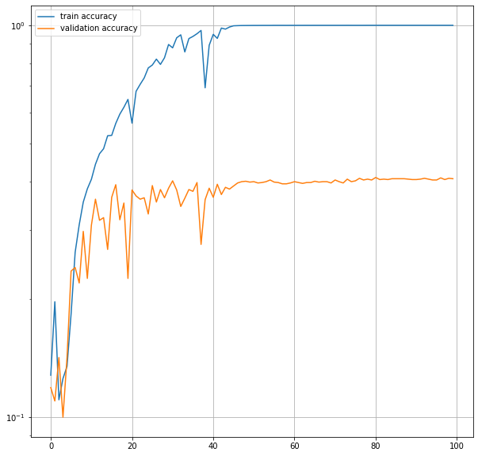

```python
# Code for training acc vs. val acc
plt.figure(figsize=(10, 10))
plt.semilogy(hist.history['accuracy'], label='train accuracy')
plt.semilogy(hist.history['val_accuracy'], label='validation accuracy')
plt.legend()
plt.grid()
```

Use your trained convnet as a feature extractor and feed the output of the flatten-layer into a **Support Vector Machine**, which now acts as a classification head (fit an SVC to your training data). Then use the fitted SVC to make predictions on your test data. Print its classification report and the confusion matrix.

```python
# Code for the conv feature extractor + SCV classifier
features = Model(
    inputs=clf_cifar10.inputs,
    outputs=clf_cifar10.layers[4].output,
)


forSVM = features.predict(Xtrain_)

print(forSVM.shape)

SVCClf = SVC(gamma='auto')
SVCClf.fit(forSVM, Ytrain.flatten())
```

```
(10000, 2048)
```

```
SVC(gamma='auto')
```

```python
# Code for making predictions
test_feature = features.predict(Xtest_)
prediction = SVCClf.predict(test_feature)
```

```python
# Code for printing classification report and confusion matrix
print(classification_report(Ytest[:,-1], prediction))
print(confusion_matrix(Ytest[:,-1], prediction))
```

```
              precision    recall  f1-score   support

           0       0.48      0.45      0.47       111
           1       0.50      0.48      0.49        89
           2       0.33      0.25      0.29       119
           3       0.32      0.26      0.29        87
           4       0.31      0.40      0.35        91
           5       0.38      0.31      0.34       113
           6       0.44      0.55      0.49        89
           7       0.50      0.55      0.53        94
           8       0.53      0.56      0.54       104
           9       0.54      0.58      0.56       103

    accuracy                           0.44      1000
   macro avg       0.43      0.44      0.43      1000
weighted avg       0.43      0.44      0.43      1000

[[50  7  5  3  6  5  3  4 21  7]
 [ 3 43  1  1  1  2  5  5  7 21]
 [12  4 30  8 23  7 15 13  5  2]
 [ 1  2 17 23  6 20  9  5  3  1]
 [ 5  1 10  4 36  7 11  7  5  5]
 [ 4  1 15 15 14 35  8 12  4  5]
 [ 0  4  5  4 14  8 49  3  1  1]
 [ 5  1  5  6 11  7  4 52  2  1]
 [17  7  3  3  3  2  2  0 58  9]
 [ 7 16  0  5  3  0  6  3  3 60]]
```

Implement a NN with the following structure:

- Input layer -> Conv block 0 -> Conv block 1 -> Conv block 2 -> Conv block 3 -> Dense layer -> Output layer
- Conv block 0: Conv2D(32, (3,3)) -> Conv2D(32, (3,3))
- Conv block 1: Conv2D(64, (3,3)) -> Conv2D(32, (3,3))
- Conv block 2: Conv2D(128, (3,3)) -> Conv2D(32, (3,3))
- Conv block 3: Conv2D(128, (3,3)) -> Conv2D(32, (3,3))
- Padding is always '**same**', kernel_initializer is '**he_uniform**', and activation function is '**relu**'
- Dense layer: layers.Flatten() -> layers.Dense(512, activation='relu')
- Output layer: layers.Dense(10)
- Train this model on the cifar-10 data for 100 epochs and make predictions on the test data
- Create a checkpoint to save the best model (see [ModelCheckpoint](https://keras.io/api/callbacks/model_checkpoint/))
- Print the classification report and confusion matrix
- Plot training loss vs. validation loss
- Plot Training accuracy vs. validation accuracy
- Did the results improve in comparison to the last model?

```python
# Code for model 2

initializer = tf.keras.initializers.HeUniform(seed=1)


def conv_block (in_size, out_size, x) :
  x = layers.Conv2D(in_size, kernel_size=(3, 3), strides=2, padding='same', activation='relu', kernel_initializer=initializer)(x)
  return layers.Conv2D(out_size, kernel_size=(3, 3), strides=2, padding='same', activation='relu', kernel_initializer=initializer)(x)


def model2(input_shape=(32,32,3), n_classes=10) :
  inx = Input(input_shape)

  x = conv_block(32, 32, inx)
  x = conv_block(64,32, x)
  x = conv_block(128,32, x)
  x = conv_block(128,32, x)

  x = layers.Flatten()(x)

  x = layers.Dense(512, activation='relu')(x)
  x = layers.Dense(n_classes)(x)
  return Model(inx, x)


model_2 = model2()
model_2.summary()

model_2.compile(loss=loss, optimizer=opt, metrics=['accuracy'])

# callback for saving model
MdlCpt2 = callbacks.ModelCheckpoint('cpt/convnet2_cifar10', save_best_only=True)

hist2 = model_2.fit(trainset, validation_data=valset, epochs=100, callbacks=[MdlCpt2])
```

```
Model: "model_4"
_________________________________________________________________
 Layer (type)                Output Shape              Param #
=================================================================
 input_3 (InputLayer)        [(None, 32, 32, 3)]       0

 conv2d_6 (Conv2D)           (None, 16, 16, 32)        896

 conv2d_7 (Conv2D)           (None, 8, 8, 32)          9248

 conv2d_8 (Conv2D)           (None, 4, 4, 64)          18496

 conv2d_9 (Conv2D)           (None, 2, 2, 32)          18464

 conv2d_10 (Conv2D)          (None, 1, 1, 128)         36992

 conv2d_11 (Conv2D)          (None, 1, 1, 32)          36896

 conv2d_12 (Conv2D)          (None, 1, 1, 128)         36992

 conv2d_13 (Conv2D)          (None, 1, 1, 32)          36896

 flatten_2 (Flatten)         (None, 32)                0

 dense_4 (Dense)             (None, 512)               16896

 dense_5 (Dense)             (None, 10)                5130

=================================================================
Total params: 216,906
Trainable params: 216,906
Non-trainable params: 0
_________________________________________________________________
```

[output not shown]

[output not shown]

[output not shown]

[output not shown]

[output not shown]

[output not shown]

[output not shown]

```
              precision    recall  f1-score   support

           0       0.00      0.00      0.00       111
           1       0.00      0.00      0.00        89
           2       0.00      0.00      0.00       119
           3       0.00      0.00      0.00        87
           4       0.00      0.00      0.00        91
           5       0.00      0.00      0.00       113
           6       0.09      1.00      0.16        89
           7       0.00      0.00      0.00        94
           8       0.00      0.00      0.00       104
           9       0.00      0.00      0.00       103

    accuracy                           0.09      1000
   macro avg       0.01      0.10      0.02      1000
weighted avg       0.01      0.09      0.01      1000

[[  0   0   0   0   0   0 111   0   0   0]
 [  0   0   0   0   0   0  89   0   0   0]
 [  0   0   0   0   0   0 119   0   0   0]
 [  0   0   0   0   0   0  87   0   0   0]
 [  0   0   0   0   0   0  91   0   0   0]
 [  0   0   0   0   0   0 113   0   0   0]
 [  0   0   0   0   0   0  89   0   0   0]
 [  0   0   0   0   0   0  94   0   0   0]
 [  0   0   0   0   0   0 104   0   0   0]
 [  0   0   0   0   0   0 103   0   0   0]]
```

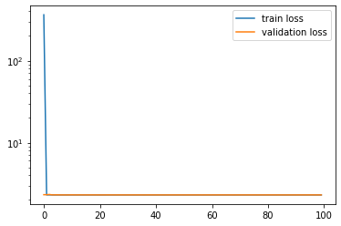

```python
# Code for prediction
pred2 = tf.argmax(model_2.predict(Xtest_), axis=-1)
# Code for classification report and confusion matric
print(classification_report(Ytest, pred2))
print(confusion_matrix(Ytest, pred2))
# Code for training loss vs. val loss
plt.semilogy(hist2.history['loss'], label='train loss')
plt.semilogy(hist2.history['val_loss'], label='validation loss')
plt.legend();
```

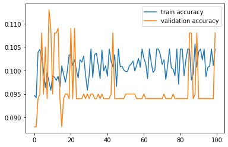

```python
# Code for training acc vs. val acc
plt.plot(hist2.history['accuracy'], label='train accuracy');
plt.plot(hist2.history['val_accuracy'], label='validation accuracy');
plt.legend()
```

For the above model, add a batch normalization layer **after each** Conv2D layer.

- Batch normalization: layers.BatchNormalization()
- You should have two batch normalization layers in each Conv block
- Train this model on the cifar-10 data for 100 epochs and make predictions on the test data
- Create a checkpoint to save the best model (see [ModelCheckpoint](https://keras.io/api/callbacks/model_checkpoint/))
- Print the classification report and confusion matrix
- Plot training loss vs. validation loss
- Plot training accuracy vs. validation accuracy
- Did the results improve in comparison to the previous two models?

```python
# Code for model 3


def conv_block_2 (in_size, out_size, x) :
  x = layers.Conv2D(in_size, kernel_size=(3, 3), strides=2, padding='same', activation='relu', kernel_initializer=initializer)(x)
  x = layers.BatchNormalization()(x)
  x = layers.Conv2D(out_size, kernel_size=(3, 3), strides=2, padding='same', activation='relu', kernel_initializer=initializer)(x)
  return layers.BatchNormalization()(x)

def model3(input_shape=(32,32,3), n_classes=10) :
  inx = Input(input_shape)

  x = conv_block_2(32, 32, inx)
  x = conv_block_2(64,32, x)
  x = conv_block_2(128,32, x)
  x = conv_block_2(128,32, x)

  x = layers.Flatten()(x)

  x = layers.Dense(512, activation='relu')(x)
  x = layers.Dense(n_classes)(x)
  return Model(inx, x)

model_3 = model3()
model_3.summary()

model_3.compile(loss=loss, optimizer=opt, metrics=['accuracy'])

# callback for saving model
MdlCpt3 = callbacks.ModelCheckpoint('cpt/convnet3_cifar10', save_best_only=True)

hist3 = model_3.fit(trainset, validation_data=valset, epochs=100, callbacks=[MdlCpt3])
```

```
Model: "model_5"
_________________________________________________________________
 Layer (type)                Output Shape              Param #
=================================================================
 input_4 (InputLayer)        [(None, 32, 32, 3)]       0

 conv2d_14 (Conv2D)          (None, 16, 16, 32)        896

 batch_normalization (BatchN  (None, 16, 16, 32)       128
 ormalization)

 conv2d_15 (Conv2D)          (None, 8, 8, 32)          9248

 batch_normalization_1 (Batc  (None, 8, 8, 32)         128
 hNormalization)

 conv2d_16 (Conv2D)          (None, 4, 4, 64)          18496

 batch_normalization_2 (Batc  (None, 4, 4, 64)         256
 hNormalization)

 conv2d_17 (Conv2D)          (None, 2, 2, 32)          18464

 batch_normalization_3 (Batc  (None, 2, 2, 32)         128
 hNormalization)

 conv2d_18 (Conv2D)          (None, 1, 1, 128)         36992

 batch_normalization_4 (Batc  (None, 1, 1, 128)        512
 hNormalization)

 conv2d_19 (Conv2D)          (None, 1, 1, 32)          36896

 batch_normalization_5 (Batc  (None, 1, 1, 32)         128
 hNormalization)

 conv2d_20 (Conv2D)          (None, 1, 1, 128)         36992

 batch_normalization_6 (Batc  (None, 1, 1, 128)        512
 hNormalization)

 conv2d_21 (Conv2D)          (None, 1, 1, 32)          36896

 batch_normalization_7 (Batc  (None, 1, 1, 32)         128
 hNormalization)

 flatten_3 (Flatten)         (None, 32)                0

 dense_6 (Dense)             (None, 512)               16896

 dense_7 (Dense)             (None, 10)                5130

=================================================================
Total params: 218,826
Trainable params: 217,866
Non-trainable params: 960
_________________________________________________________________
```

[output not shown]

[output not shown]

[output not shown]

[output not shown]

[output not shown]

[output not shown]

[output not shown]

[output not shown]

[output not shown]

[output not shown]

[output not shown]

```python
# Code for prediction
pred3 = tf.argmax(model_3.predict(Xtest_), axis=-1)
# Code for classification report and confusion matrix
print(classification_report(Ytest, pred3))
print(confusion_matrix(Ytest, pred3))
```

```
              precision    recall  f1-score   support

           0       0.57      0.45      0.50       111
           1       0.63      0.47      0.54        89
           2       0.41      0.29      0.34       119
           3       0.26      0.33      0.29        87
           4       0.31      0.48      0.38        91
           5       0.39      0.39      0.39       113
           6       0.49      0.57      0.53        89
           7       0.48      0.49      0.49        94
           8       0.69      0.62      0.65       104
           9       0.60      0.60      0.60       103

    accuracy                           0.47      1000
   macro avg       0.48      0.47      0.47      1000
weighted avg       0.48      0.47      0.47      1000

[[50  3 12  4 11  6  2  6 11  6]
 [ 3 42  0  8  0  8  1  2  6 19]
 [ 5  0 34 15 32 10 12  8  1  2]
 [ 1  1  7 29  8 21 10  6  3  1]
 [ 2  0  8  8 44  3 11 12  1  2]
 [ 1  2 11 21 10 44  9 10  2  3]
 [ 0  0  3 11 14  7 51  1  1  1]
 [ 5  0  5  5 19  8  2 46  1  3]
 [16  6  2  3  3  3  1  1 64  5]
 [ 5 13  1  6  1  4  5  3  3 62]]
```

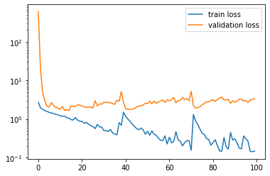

```python
# Code for training loss vs. val loss
plt.semilogy(hist3.history['loss'], label='train loss')
plt.semilogy(hist3.history['val_loss'], label='validation loss')
plt.legend();
```

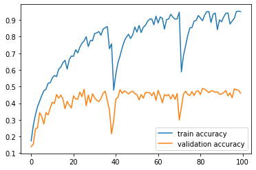

```python
# Code for training acc vs. val acc
plt.plot(hist3.history['accuracy'], label='train accuracy');
plt.plot(hist3.history['val_accuracy'], label='validation accuracy');
plt.legend()
```

Apply the following changes to the previous model:

- In Conv block 0: add a Dropout layer with a rate of 0.1 after the second batch normalization layer
- In Conv block 1: add a Dropout layer with a rate of 0.2 after the second batch normalization layer
- In Conv block 2: add a Dropout layer with a rate of 0.3 after the second batch normalization layer
- In Conv block 3: add a Dropout layer with a rate of 0.4 after the second batch normalization layer
- Add a Dropout layer after the Dense layer with rate 0.5
- Dropout layer: layers.Dropout(rate)
- Train this model on the cifar-10 data for 100 epochs and make predictions on the test data
- Create a checkpoint to save the best model (see [ModelCheckpoint](https://keras.io/api/callbacks/model_checkpoint/))
- Print the classification report and confusion matrix
- Plot training loss vs. validation loss
- Plot training accuracy vs. validation accuracy
- Did the results improve in comparison to the previous models?

```python
# Code for model 4


def conv_block_3 (in_size, out_size, x, drop_rate) :
  x = layers.Conv2D(in_size, kernel_size=(3, 3), strides=2, padding='same', activation='relu', kernel_initializer=initializer)(x)
  x = layers.BatchNormalization()(x)
  x = layers.Conv2D(out_size, kernel_size=(3, 3), strides=2, padding='same', activation='relu', kernel_initializer=initializer)(x)
  x = layers.BatchNormalization()(x)
  return layers.Dropout(drop_rate)(x)

def model4(input_shape=(32,32,3), n_classes=10) :
  inx = Input(input_shape)

  x = conv_block_3(32, 32, inx, 0.1)
  x = conv_block_3(64,32, x, 0.2)
  x = conv_block_3(128,32, x, 0.3)
  x = conv_block_3(128,32, x, 0.4)

  x = layers.Flatten()(x)

  x = layers.Dense(512, activation='relu')(x)
  x = layers.Dropout(0.5)(x)
  x = layers.Dense(n_classes)(x)

  return Model(inx, x)


model_4 = model4()
model_4.summary()

model_4.compile(loss=loss, optimizer=opt, metrics=['accuracy'])

# callback for saving model
MdlCpt4 = callbacks.ModelCheckpoint('cpt/convnet4_cifar10', save_best_only=True)

hist4 = model_4.fit(trainset, validation_data=valset, epochs=100, callbacks=[MdlCpt4])
```

```
Model: "model_6"
_________________________________________________________________
 Layer (type)                Output Shape              Param #
=================================================================
 input_5 (InputLayer)        [(None, 32, 32, 3)]       0

 conv2d_22 (Conv2D)          (None, 16, 16, 32)        896

 batch_normalization_8 (Batc  (None, 16, 16, 32)       128
 hNormalization)

 conv2d_23 (Conv2D)          (None, 8, 8, 32)          9248

 batch_normalization_9 (Batc  (None, 8, 8, 32)         128
 hNormalization)

 dropout (Dropout)           (None, 8, 8, 32)          0

 conv2d_24 (Conv2D)          (None, 4, 4, 64)          18496

 batch_normalization_10 (Bat  (None, 4, 4, 64)         256
 chNormalization)

 conv2d_25 (Conv2D)          (None, 2, 2, 32)          18464

 batch_normalization_11 (Bat  (None, 2, 2, 32)         128
 chNormalization)

 dropout_1 (Dropout)         (None, 2, 2, 32)          0

 conv2d_26 (Conv2D)          (None, 1, 1, 128)         36992

 batch_normalization_12 (Bat  (None, 1, 1, 128)        512
 chNormalization)

 conv2d_27 (Conv2D)          (None, 1, 1, 32)          36896

 batch_normalization_13 (Bat  (None, 1, 1, 32)         128
 chNormalization)

```

[output cut: 12 more lines]

```
 dropout_3 (Dropout)         (None, 1, 1, 32)          0

 flatten_4 (Flatten)         (None, 32)                0

 dense_8 (Dense)             (None, 512)               16896

 dropout_4 (Dropout)         (None, 512)               0

 dense_9 (Dense)             (None, 10)                5130

=================================================================
Total params: 218,826
Trainable params: 217,866
Non-trainable params: 960
_________________________________________________________________
```

[output not shown]

[output not shown]

[output not shown]

[output not shown]

[output not shown]

[output not shown]

[output not shown]

[output not shown]

[output not shown]

[output not shown]

[output not shown]

[output not shown]

[output not shown]

[output not shown]

[output not shown]

[output not shown]

[output not shown]

```python
# Code for prediction
pred4 = tf.argmax(model_4.predict(Xtest_), axis=-1)
# Code for classification report and confusion matrix
print(classification_report(Ytest, pred4))
print(confusion_matrix(Ytest, pred4))
```

```
              precision    recall  f1-score   support

           0       0.51      0.68      0.58       111
           1       0.70      0.42      0.52        89
           2       0.57      0.21      0.31       119
           3       0.22      0.25      0.24        87
           4       0.38      0.42      0.40        91
           5       0.47      0.52      0.50       113
           6       0.60      0.66      0.63        89
           7       0.60      0.68      0.64        94
           8       0.75      0.38      0.50       104
           9       0.44      0.76      0.56       103

    accuracy                           0.50      1000
   macro avg       0.52      0.50      0.49      1000
weighted avg       0.53      0.50      0.49      1000

[[75  0  5  4  2  1  2  5  5 12]
 [ 6 37  0  1  0  0  0  0  4 41]
 [17  0 25 15 35  8  9  3  0  7]
 [ 2  0  4 22  2 39  9  6  0  3]
 [ 5  0  5  9 38  5 12 12  1  4]
 [ 3  0  2 22  4 59  5 14  0  4]
 [ 1  0  1 10 11  1 59  1  0  5]
 [ 3  0  1  5  7  9  0 64  1  4]
 [31  6  0  6  1  2  1  0 39 18]
 [ 4 10  1  4  0  1  2  1  2 78]]
```

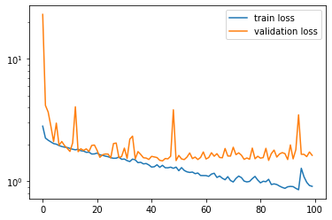

```python
# Code for training loss vs. val loss
plt.semilogy(hist4.history['loss'], label='train loss')
plt.semilogy(hist4.history['val_loss'], label='validation loss')
plt.legend();
```

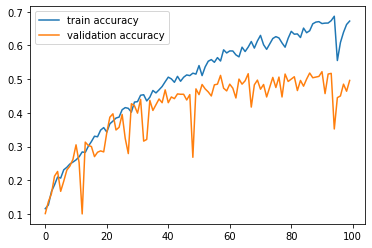

```python
# Code for training acc vs. val acc
plt.plot(hist4.history['accuracy'], label='train accuracy');
plt.plot(hist4.history['val_accuracy'], label='validation accuracy');
plt.legend()
```

Apply [image augmentation](https://www.tensorflow.org/tutorials/images/data_augmentation) to the previous model. You can use random translation, random flip, and random rotation.

- Train this model on the cifar-10 data for 200 epochs and make predictions on the test data
- Create a checkpoint to save the best model (see [ModelCheckpoint](https://keras.io/api/callbacks/model_checkpoint/))
- Print the classification report and confusion matrix
- Plot training loss vs. validation loss
- Plot training accuracy vs. validation accuracy
- Did the results improve in comparison to the previous models?

```python
# Code for image augmentation + the rest of the tasks mentioned above
def model5(input_shape=(32,32,3), n_classes=10) :
  inx = Input(input_shape)
    # image augmentation
  x = layers.RandomFlip()(inx)
  x = layers.RandomRotation(0.2)(x)
  x = layers.RandomTranslation(0.2,0.2)(x)

  x = conv_block_3(32, 32, inx, 0.1)
  x = conv_block_3(64,32, x, 0.2)
  x = conv_block_3(128,32, x, 0.3)
  x = conv_block_3(128,32, x, 0.4)

  x = layers.Flatten()(x)

  x = layers.Dense(512, activation='relu')(x)
  x = layers.Dropout(0.5)(x)
  x = layers.Dense(n_classes)(x)

  return Model(inx, x)


model_5 = model5()
model_5.summary()

model_5.compile(loss=loss, optimizer=opt, metrics=['accuracy'])

# callback for saving model
MdlCpt5 = callbacks.ModelCheckpoint('cpt/convnet5_cifar10', save_best_only=True)

hist5 = model_5.fit(trainset, validation_data=valset, epochs=200, callbacks=[MdlCpt5])
```

```
Model: "model_7"
_________________________________________________________________
 Layer (type)                Output Shape              Param #
=================================================================
 input_6 (InputLayer)        [(None, 32, 32, 3)]       0

 conv2d_30 (Conv2D)          (None, 16, 16, 32)        896

 batch_normalization_16 (Bat  (None, 16, 16, 32)       128
 chNormalization)

 conv2d_31 (Conv2D)          (None, 8, 8, 32)          9248

 batch_normalization_17 (Bat  (None, 8, 8, 32)         128
 chNormalization)

 dropout_5 (Dropout)         (None, 8, 8, 32)          0

 conv2d_32 (Conv2D)          (None, 4, 4, 64)          18496

 batch_normalization_18 (Bat  (None, 4, 4, 64)         256
 chNormalization)

 conv2d_33 (Conv2D)          (None, 2, 2, 32)          18464

 batch_normalization_19 (Bat  (None, 2, 2, 32)         128
 chNormalization)

 dropout_6 (Dropout)         (None, 2, 2, 32)          0

 conv2d_34 (Conv2D)          (None, 1, 1, 128)         36992

 batch_normalization_20 (Bat  (None, 1, 1, 128)        512
 chNormalization)

 conv2d_35 (Conv2D)          (None, 1, 1, 32)          36896

 batch_normalization_21 (Bat  (None, 1, 1, 32)         128
 chNormalization)

```

[output cut: 12 more lines]

```
 dropout_8 (Dropout)         (None, 1, 1, 32)          0

 flatten_5 (Flatten)         (None, 32)                0

 dense_10 (Dense)            (None, 512)               16896

 dropout_9 (Dropout)         (None, 512)               0

 dense_11 (Dense)            (None, 10)                5130

=================================================================
Total params: 218,826
Trainable params: 217,866
Non-trainable params: 960
_________________________________________________________________
```

[output not shown]

[output not shown]

[output not shown]

[output not shown]

[output not shown]

[output not shown]

[output not shown]

[output not shown]

[output not shown]

[output not shown]

[output not shown]

[output not shown]

[output not shown]

[output not shown]

[output not shown]

[output not shown]

[output not shown]

[output not shown]

[output not shown]

[output not shown]

[output not shown]

[output not shown]

```
              precision    recall  f1-score   support

           0       0.50      0.55      0.52       111
           1       0.72      0.61      0.66        89
           2       0.19      0.07      0.10       119
           3       0.20      0.33      0.25        87
           4       0.27      0.64      0.38        91
           5       0.45      0.27      0.34       113
           6       0.68      0.36      0.47        89
           7       0.63      0.61      0.62        94
           8       0.66      0.64      0.65       104
           9       0.65      0.64      0.65       103

    accuracy                           0.46      1000
   macro avg       0.50      0.47      0.46      1000
weighted avg       0.49      0.46      0.46      1000

[[61  0  9  6 12  0  0  2 16  5]
 [ 9 54  2  3  0  0  0  0  5 16]
 [17  1  8 21 59  3  4  4  1  1]
 [ 3  0  5 29 16 23  1  8  1  1]
 [ 5  0  3  8 58  2  4  8  1  2]
 [ 2  0  2 44 23 30  4  4  2  2]
 [ 2  1  6 15 27  2 32  1  0  3]
 [ 2  0  4  9 13  5  1 57  1  2]
 [18  4  2  6  3  0  1  0 67  3]
 [ 3 15  2  2  0  1  0  6  8 66]]
```

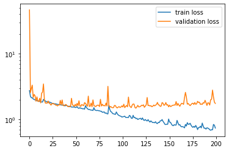

```python
# Code for prediction
pred5 = tf.argmax(model_5.predict(Xtest_), axis=-1)
# Code for classification report and confusion matrix
print(classification_report(Ytest, pred5))
print(confusion_matrix(Ytest, pred5))

# Code for training loss vs. val loss
plt.semilogy(hist5.history['loss'], label='train loss')
plt.semilogy(hist5.history['val_loss'], label='validation loss')
plt.legend();
```

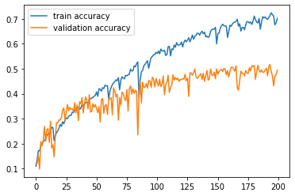

```python
# Code for training acc vs. val acc
plt.plot(hist5.history['accuracy'], label='train accuracy');
plt.plot(hist5.history['val_accuracy'], label='validation accuracy');
plt.legend()
```

Create 3D scatter plots (per class) of the first 3 principal components on:

- Raw images
- Simple Convnet features
- Features of the best performing model

Describe your observation from the three plots

```
(10000, 3)
```

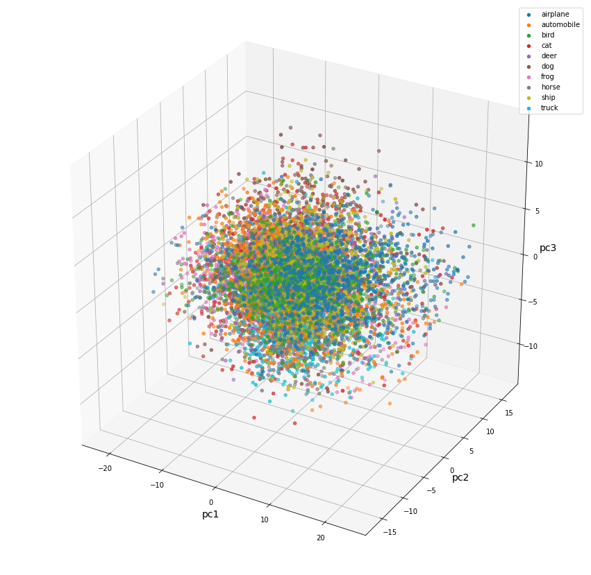

```
(10000, 3)
```

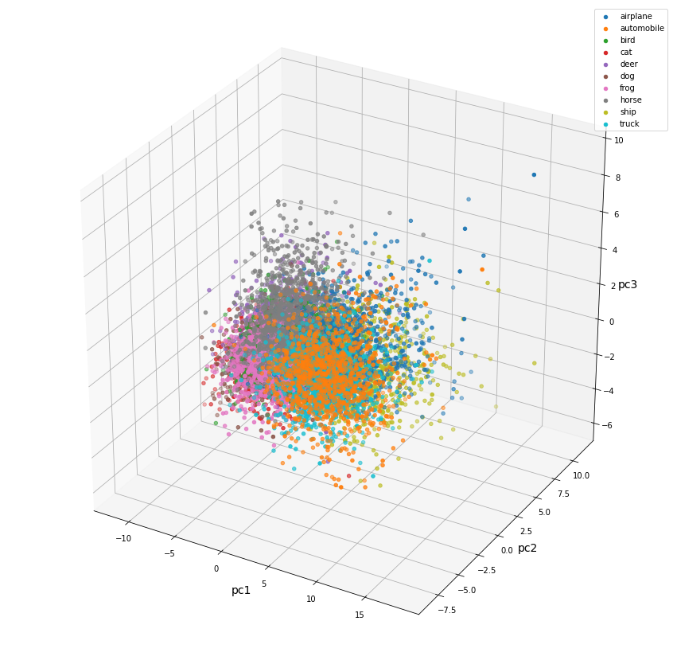

```
(10000, 3)
```

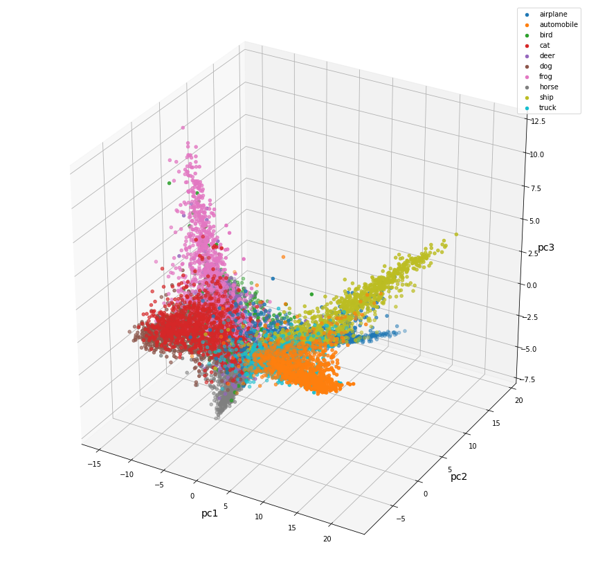

```python
# Code for the three different 3D scatter plots

def make_plot (x, y) :
  pca = PCA(n_components=3)
  pc_fit = pca.fit_transform(x, y)

  fig = plt.figure(figsize=(15,15))
  ax = fig.add_subplot(projection='3d')

  print(pc_fit.shape)


  #ax.scatter(pc_fit[:,0], pc_fit[:,1], pc_fit[:,2], y[:])
  for l in np.unique(y):
    xax = np.take(pc_fit, np.where(y == l), axis=0)
    ax.scatter(xax[0, :, 0], xax[0, :, 1], xax[0, :, 2], label=classes[l])


  ax.set_xlabel("pc1", fontsize=14)
  ax.set_ylabel("pc2", fontsize=14)
  ax.set_zlabel("pc3", fontsize=14)

  ax.legend()
  plt.show()


# Plots

make_plot(Xtrain_.reshape(-1,32*32*3),Ytrain.flatten())

simple = tf.keras.models.load_model('cpt/convnet_cifar10_1')
make_plot(simple(Xtrain_), Ytrain.flatten())

best = tf.keras.models.load_model('cpt/convnet4_cifar10')
make_plot(best(Xtrain_), Ytrain.flatten())
```